# Quality of the Model Fit

Dr. Josh Jacobson

28 January 2026

*These lecture notes were originally developed by Dr. Kris Pruitt.*

The purpose of this lesson is to compute and interpret common metrics for how well a simple linear regression model fits the training data. Specifically, we discuss residual standard error and the coefficient of determination.

# Residual Standard Error

In the previous lessons, we conducted inferential analyses to assess evidence of an association between an explanatory variable $x$ and a response variable $y$. When we find evidence of *some* association, the next logical question is “how strong” is the association. Said another way, we often want to know how well the linear model fits the sample data. This is a different metric than prediction accuracy (e.g., root mean squared error) on a testing set. Measures of fit refer to how well the model aligns with the *training* data set.

The first measure of fit is known as the **residual standard error (RSE)**. Recall that the least squares method seeks to minimize the sum of squared errors in the linear model $y=\beta_0 +\beta_1 x + \epsilon$. This is sometimes referred to as the **residual sum of squares (RSS)**.

$$\begin{aligned}
\text{RSS} &= \sum_i \epsilon_i^2 \\
&=\sum_i (y_i-\hat{y}_i)^2 \\
&=\sum_i (y_i-\hat{\beta}_0-\hat{\beta}_1 x_i)^2
\end{aligned}$$

The RSS indicates the total squared error for the model fit to the training set. A more useful metric is to convert RSS to the *average error* incurred by the model. This is the purpose of RSE.

$$\text{RSE} = \sqrt{\frac{\text{RSS}}{n-(p+1)}}$$

When averaging the squared error we divide by $n-(p+1)$, where $n$ is the number of observations and $p$ is the number of predictors. In the case of simple linear regression, this adjustment is meant to correct for the bias introduced when estimating $p+1=2$ model parameters ($\beta_0,\beta_1$). We can think of RSE as the average deviation between the response values and the best-fit line in the training set. Another interpretation of RSE is the standard deviation of the irreducible error $\epsilon$ in the linear regression model. In fact, many texts refer to RSE as an estimate of $\sigma$, the true error standard deviation. Let’s compute RSE for a familiar example.

We will return to the data set regarding the gestation period of babies from the early 1960s. Load the required packages and import the `Gestation` data frame. We are again interested in the association between gestation period (months) and birth weight (pounds). We begin by wrangling the data and visualizing the association in a scatter plot.

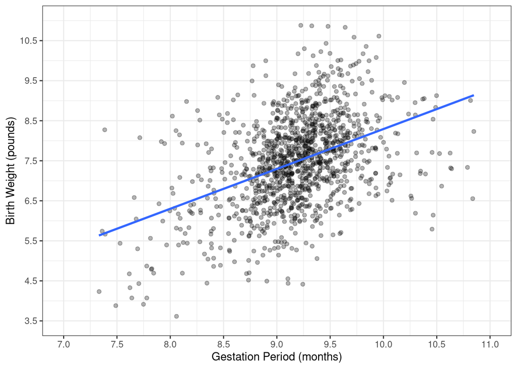

```r
# load packages
library(mosaicData)

# import data
data(Gestation)

# wrangle data
births <- Gestation %>%
  transmute(
    months = gestation / 30.42,
    weight = wt / 16
  ) %>%
  na.omit() %>%
  filter(months > 7, months < 11)

# plot gestation versus weight
ggplot(data = births, aes(x = months, y = weight)) +
  geom_point(position = "jitter", alpha = 0.3) +
  geom_smooth(method = "lm", se = FALSE) +
  scale_x_continuous(limits = c(7, 11), breaks = seq(7, 11, 0.5)) +
  scale_y_continuous(limits = c(3.5, 11), breaks = seq(3.5, 11, 1)) +
  labs(
    x = "Gestation Period (months)",
    y = "Birth Weight (pounds)"
  ) +
  theme_bw()
```

As before, there appears to be a weak, increasing, linear association between gestation period and birth weight. Next we can fit a simple linear regression model of this association using the `lm()` function and display the full summary output. Here we are treating the full sample as the training data.

```r
# fit regression model
model <- lm(weight ~ months, data = births)

# display model statistics
summary(model)
```

```
##
## Call:
## lm(formula = weight ~ months, data = births)
##
## Residuals:
##     Min      1Q  Median      3Q     Max
## -3.0954 -0.6862  0.0058  0.6226  3.3421
##
## Coefficients:
##             Estimate Std. Error t value Pr(>|t|)
## (Intercept) -1.66733    0.56028  -2.976  0.00298 **
## months       0.99598    0.06092  16.349  < 2e-16 ***
## ---
## Signif. codes:  0 '***' 0.001 '**' 0.01 '*' 0.05 '.' 0.1 ' ' 1
##
## Residual standard error: 1.029 on 1214 degrees of freedom
## Multiple R-squared:  0.1804, Adjusted R-squared:  0.1798
## F-statistic: 267.3 on 1 and 1214 DF,  p-value: < 2.2e-16
```

Beyond the coefficient estimates, we now also see a row for `Residual standard error` with a value of 1.029. Thus, the birth weights in the training data differ from the best-fit line by an average of just over one pound. The automated calculation of RSE is a nice feature of the summary output. Otherwise, we would have to compute it ourselves as follows.

```r
# compute RSE
births %>%
  mutate(weight_hat = 0.99598 * months - 1.66733) %>%
  summarize(RSE = sqrt(sum((weight - weight_hat)^2) / 1214))
```

| RSE |
| --- |
| 1.029201 |

In general, a smaller RSE suggests a model that better fits the training data. However, it is up to domain experts to decide whether the error is acceptable in the context of the associated research.

# Coefficient of Determination

Another common measure of fit for linear regression models is known as the **coefficient of determination**. But most people refer to it as $R^2$. The letter $R$ refers to its relationship with the correlation coefficient, which often uses a lower case $r$ as notation. The historical use of $r$ for correlation actually refers to “reversion” or “regression” to the mean. In the context of *simple* linear regression, $R^2$ is literally the square of the correlation coefficient. The formula for the correlation coefficient is complex, so we typically employ software to avoid mistakes. Let’s demonstrate this for the `Gestation` data.

```r
# compute correlation
cor(births$weight, births$months, )
```

```
## [1] 0.4247783
```

The correlation between months of gestation and birth weight is +0.42. Using the typical categorizations of correlation below, we refer to this association as “weak” and positive.

- Strong: 1 to 0.75
- Moderate: 0.75 to 0.50
- Weak: 0.50 to 0.25
- None: 0.25 to 0

By squaring this value, we obtain the coefficient of determination.

```r
# compute R-squared
cor(births$weight, births$months)^2
```

```
## [1] 0.1804366
```

Returning to the summary output for the regression model, we see a row with `Multiple R-squared` and a value of 0.1804. Thus, as with RSE, there is no need to compute $R^2$ manually. In general, values close to 1 indicate a model that fits the data very well, while values close to 0 indicate a poor fit. Consequently, our model for birth weight is relatively weak.

Another popular interpretation of $R^2$ is the “proportion of variance explained” by the model. In this case, we refer to the proportion of variance in the response variable. For the gestation example, 18% of the variance in birth weight can be explained by its linear association with months in the womb. As a result, most of the variability in birth weight remains unexplained. It could be that better explanatory variables exist or that there is simply a great deal of irreducible error in modeling birth weight.

This alternative interpretation for $R^2$ results from a different method of calculation. Namely, we can compute the coefficient of determination in the following way.

$$R^2=1-\frac{\text{RSS}}{\text{TSS}}$$

The value for RSS is the same as previously described. The **total sum of squares (TSS)** is derived from the error associated with using the *average* response rather than a regression model. We often refer to the average response as the “null” model.

$$\text{TSS}=\sum_i (y_i-\bar{y})^2$$

For the gestation example, the mean birth weight in the training data is 7.48 pounds. Thus, we could manually compute RSS and TSS as follows.

```r
# compute TSS
births %>%
  mutate(
    weight_hat = 0.99598 * months - 1.66733,
    weight_bar = 7.48
  ) %>%
  summarize(
    RSS = sum((weight - weight_hat)^2),
    TSS = sum((weight - weight_bar)^2)
  )
```

| RSS | TSS |
| --- | --- |
| 1285.936 | 1569.05 |

The ratio of RSS to TSS represents the proportion of variance *remaining* in the model. In this case, about 82% (1285.936/1569.050) of the variance in birth weight remains in the model. By subtracting this proportion from 1, we obtain the variance eliminated (aka “explained”). So, 18% of the variance in birth weight is eliminated by our model.